# Macroinvert multivariate

Matt Brousil

2020-02-03

### Multivariate macroinvertebrate exploration

```r
library(tidyverse)
library(readxl)
library(vegan)
library(labdsv)
```

```r
library(kableExtra)
library(viridis)
library(visdat)
library(corrplot)
library(psych)
library(ggvegan)
library(ggpubr)
```

#### Load the data

```r
# Macroinvert data
macro_counts <- read_excel(path = "../data/NCCN_ML_BMI_Counts_FCA_2019JUL09.xlsx",
                           sheet = "BMI_Counts")

head(macro_counts)
```

```
## # A tibble: 6 x 10
##   Park  Site_ID  Year Sample_ID Taxon Count Life_Stage Unique `Not Unique`
##   <chr> <chr>   <dbl> <chr>     <chr> <dbl> <chr>      <chr>  <chr>
## 1 MORA  LH14     2008 MORA_LH1~ Chao~     1 L          NA     NA
## 2 MORA  LH14     2008 MORA_LH1~ Chao~     1 P          NA     NA
## 3 MORA  LH14     2008 MORA_LH1~ Cory~     1 L          NA     NA
## 4 MORA  LH14     2008 MORA_LH1~ Prot~     2 L          NA     NA
## 5 MORA  LH14     2008 MORA_LH1~ Helo~     2 U          NA     NA
## 6 MORA  LH14     2008 MORA_LH1~ Hete~     2 L          NA     NA
## # ... with 1 more variable: Taxonomist <chr>
```

```r
# Lookup table for macro taxonomy
macro_lookup <- read_excel(path = "../data/NCCN_ML_BMI_Counts_FCA_2019JUL09.xlsx",
                           sheet = "Taxon_Lookup")

head(macro_lookup)
```

```
## # A tibble: 6 x 12
##   Taxa_Code Taxon Phylum Subphylum Class Subclass Order Suborder Family
##   <chr>     <chr> <chr>  <chr>     <chr> <chr>    <chr> <chr>    <chr>
## 1 Acari     Acari Arthr~ Chelicer~ Arac~ Acari    _Aca~ <NA>     <NA>
## 2 B_V_Sph   Spha~ Mollu~ <NA>      Biva~ Heterod~ Vene~ <NA>     Sphae~
## 3 B_V_Sph_~ Musc~ Mollu~ <NA>      Biva~ Heterod~ Vene~ <NA>     Sphae~
## 4 B_V_Sph_~ Pisi~ Mollu~ <NA>      Biva~ Heterod~ Vene~ <NA>     Sphae~
## 5 B_V_Sph_~ Spha~ Mollu~ <NA>      Biva~ Heterod~ Vene~ <NA>     Sphae~
## 6 Br_D_Chy  Chyd~ Arthr~ Crustacea Bran~ Phyllop~ Dipl~ Cladoce~ Chydo~
## # ... with 3 more variables: Subfamily <chr>, Genus <chr>, Sp_epithet <chr>
```

```r
# Environmental data
bigjoin <- readRDS(file = "../data/analysis_outputs/bigjoin.rds")
```

#### 1. How well do the macroinvert count data match the taxa lookup list provided?

```r
unique_counts <- unique(macro_counts$Taxon)
unique_lookup <- unique(macro_lookup$Taxon)
```

Which taxa in the counts data aren’t in the lookup table? (result = 4)

```r
unique_counts[!(unique_counts %in% unique_lookup)]
```

```
## [1] "Orthocladius Complex"         "Thienemannimyia Complex"
## [3] "Microtendipes pedellus group" "Tvetenia bavarica group"
```

Which taxa in lookup aren’t in counts? (result = 0)

```r
unique_lookup[!(unique_lookup %in% unique_counts)]
```

```
## character(0)
```

**The lists are pretty well matched.** SH suggested going up to order for multivariate work. I’ll go ahead and join the count data to the lookup data to move towards this. There’s also a row with NA count data, so I remove it.

```r
full_macro <- inner_join(x = macro_counts, y = macro_lookup, by = c("Taxon"))

# summary(full_macro)

full_macro <- full_macro %>%
  filter(!is.na(Count))
```

Data broken down by order:

```r
full_macro %>%
  group_by(Order) %>%
  summarize(total_counts = sum(Count)) %>%
  arrange(desc(total_counts))
```

```
## # A tibble: 23 x 2
##    Order         total_counts
##    <chr>                <dbl>
##  1 Diptera              46240
##  2 _Oligo                8934
##  3 Amphipoda             4804
##  4 Veneroida             4365
##  5 Ephemeroptera         3839
##  6 Coleoptera            3347
##  7 _Acari                2144
##  8 Trichoptera           1751
##  9 _Ostra                 898
## 10 _Ntoda                 690
## # ... with 13 more rows
```

#### 2. NMDS prep and plot

```r
# Aggregate to order and filter out those <= 5% of the representation
macro_comm <- full_macro %>%
  group_by(Park, Site_ID, Year, Order) %>%
  summarise(sum_order_count = sum(Count)) %>%
  group_by(Park, Site_ID, Year) %>%
  mutate(sum_all_count = sum(sum_order_count, na.rm = TRUE)) %>%
  ungroup() %>%
  mutate(prop_order = sum_order_count / sum_all_count) %>%
  # This drops 703 rows
  filter(prop_order >= 0.05)

# Add a row identifier column, turn into matrix
macro_comm_matrix <- macro_comm %>%
  mutate(park_site_year = paste0(Park, "_", Site_ID, "_", Year)) %>%
  select(park_site_year, Order, sum_order_count) %>%
  data.frame() %>%
  matrify()
```

Standardize to relative abundance per site

```r
macro_std <- decostand(x = macro_comm_matrix, method = "total")

head(macro_std)
```

```
##                _Acari _Ntoda    _Ntopda     _Oligo     _Ostra _Platy Amphipoda
## MORA_LH14_2008      0      0 0.06228956 0.71885522 0.00000000      0         0
## MORA_LH14_2009      0      0 0.00000000 0.60560345 0.00000000      0         0
## MORA_LH14_2010      0      0 0.00000000 0.05420561 0.00000000      0         0
## MORA_LH14_2011      0      0 0.00000000 0.22199170 0.00000000      0         0
## MORA_LH14_2012      0      0 0.00000000 0.26875000 0.00000000      0         0
## MORA_LH14_2013      0      0 0.00000000 0.43663472 0.05963791      0         0
##                Coleoptera Diplostraca    Diptera Ephemeroptera Megaloptera
## MORA_LH14_2008 0.00000000           0 0.08585859     0.1329966           0
## MORA_LH14_2009 0.09698276           0 0.11853448     0.1788793           0
## MORA_LH14_2010 0.40934579           0 0.42616822     0.1102804           0
## MORA_LH14_2011 0.17842324           0 0.59958506     0.0000000           0
## MORA_LH14_2012 0.41250000           0 0.31875000     0.0000000           0
## MORA_LH14_2013 0.17145900           0 0.00000000     0.3322684           0
##                Odonata Trichoptera Veneroida
## MORA_LH14_2008       0           0         0
## MORA_LH14_2009       0           0         0
## MORA_LH14_2010       0           0         0
## MORA_LH14_2011       0           0         0
## MORA_LH14_2012       0           0         0
## MORA_LH14_2013       0           0         0
```

Should sum to 1 within rows:

```r
sum(macro_std[1, ])
```

```
## [1] 1
```

Scree plot for an NMDS

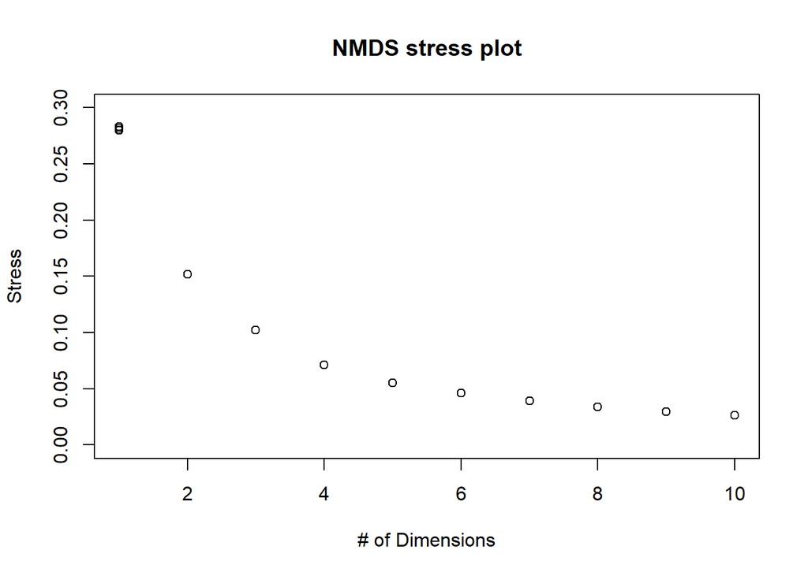

```r
# Adapted from https://ourcodingclub.github.io/2018/05/04/ordination.html
scree_plot <- function(x) { #where x is the name of the data frame variable
  plot(rep(1, 10),
       replicate(10, metaMDS(comm = x, distance = "bray", k = 1)$stress),
       xlim = c(1, 10),ylim = c(0, 0.30), xlab = "# of Dimensions",
       ylab = "Stress", main = "NMDS stress plot")
  for (i in 1:10) {
    points(rep(i + 1,10),replicate(10, metaMDS(x,  distance = "bray", k = i + 1)$stress))
  }
}

scree_plot(macro_std)
```

#### How do 2- and 3-dimensional NDMS perform?

```r
nmds_2 <- metaMDS(comm = macro_std, distance = "bray", k = 2, trymax = 100)
```

```r
nmds_2
```

```
##
## Call:
## metaMDS(comm = macro_std, distance = "bray", k = 2, trymax = 100)
##
## global Multidimensional Scaling using monoMDS
##
## Data:     macro_std
## Distance: bray
##
## Dimensions: 2
## Stress:     0.1520092
## Stress type 1, weak ties
## Two convergent solutions found after 37 tries
## Scaling: centring, PC rotation, halfchange scaling
## Species: expanded scores based on 'macro_std'
```

A three-dimensional NMDS converges:

```r
nmds_3 <- metaMDS(comm = macro_std, distance = "bray", k = 3, trymax = 100)
```

```r
nmds_3
```

```
##
## Call:
## metaMDS(comm = macro_std, distance = "bray", k = 3, trymax = 100)
##
## global Multidimensional Scaling using monoMDS
##
## Data:     macro_std
## Distance: bray
##
## Dimensions: 3
## Stress:     0.1020786
## Stress type 1, weak ties
## Two convergent solutions found after 28 tries
## Scaling: centring, PC rotation, halfchange scaling
## Species: expanded scores based on 'macro_std'
```

#### Let’s plot it:

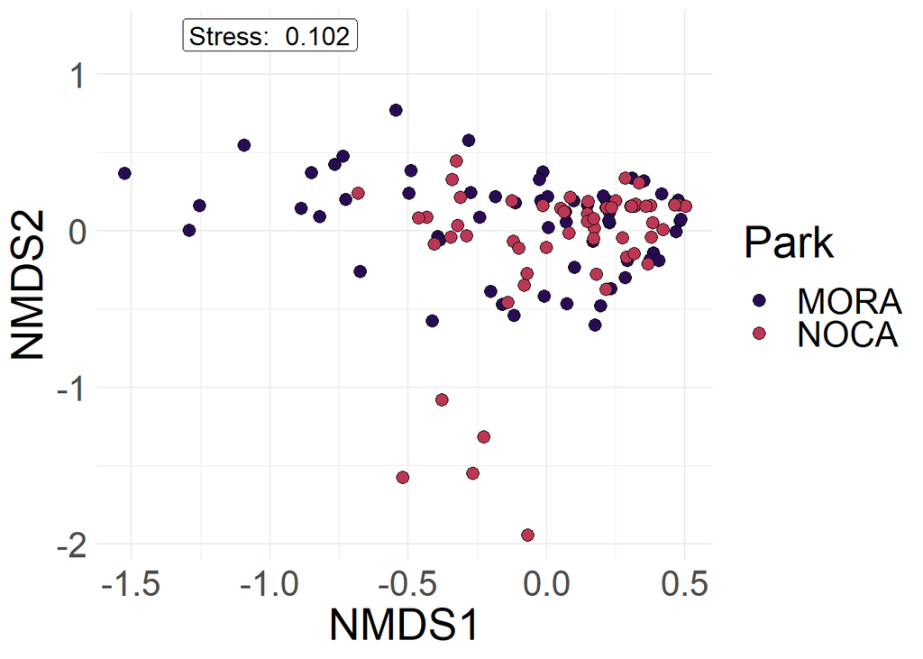

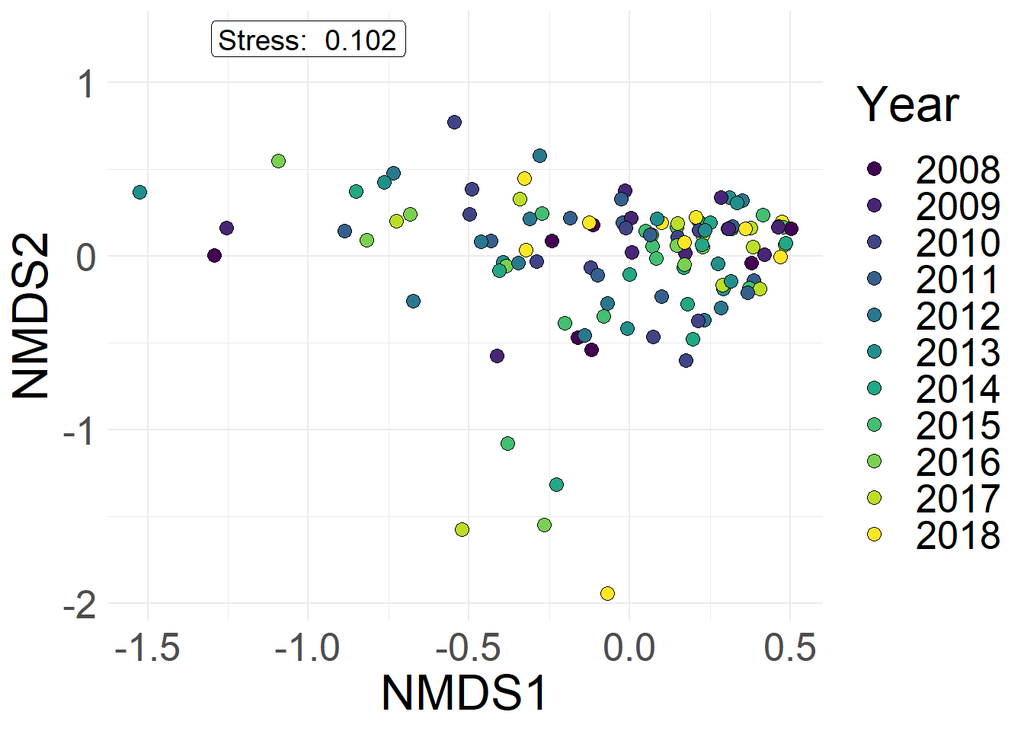

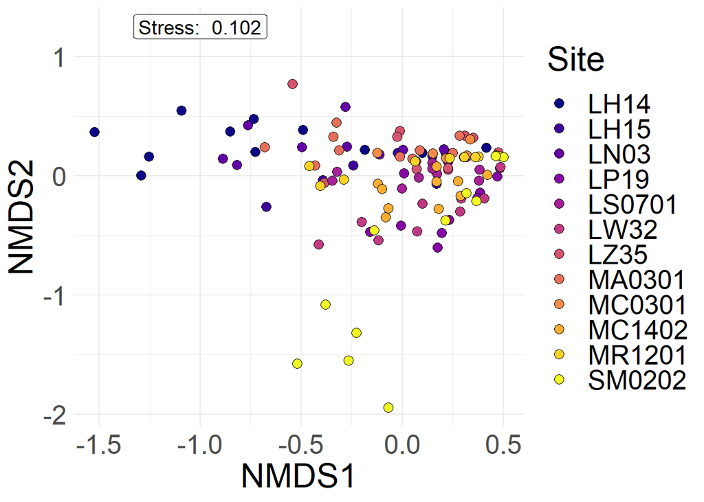

```r
macro_std_ids <- rownames_to_column(macro_std) %>%
  separate(col = rowname, into = c("park", "site", "year"), sep = "_")

macro_permanova <- adonis(formula = select(macro_std_ids, `_Acari`:Veneroida) ~ year + site,
                          data = macro_std_ids, method = "bray")

macro_permanova
```

```
##
## Call:
## adonis(formula = select(macro_std_ids, `_Acari`:Veneroida) ~      year + site, data = macro_std_ids, method = "bray")
##
## Permutation: free
## Number of permutations: 999
##
## Terms added sequentially (first to last)
##
##            Df SumsOfSqs MeanSqs F.Model      R2 Pr(>F)
## year       10    0.7906 0.07906  1.0719 0.05479  0.331
## site       11    5.9671 0.54246  7.3545 0.41356  0.001 ***
## Residuals 104    7.6710 0.07376         0.53165
## Total     125   14.4286                 1.00000
## ---
## Signif. codes:  0 '***' 0.001 '**' 0.01 '*' 0.05 '.' 0.1 ' ' 1
```

#### 3. Make some univariate plots to look at similar metrics

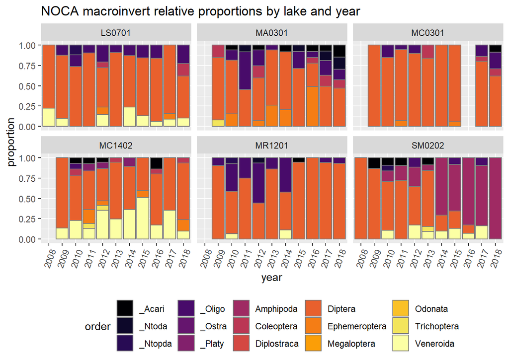

```r
# Reshape the proportion community data into a useful data frame for ggplot2
macro_props <- as.data.frame(macro_std) %>%
  bind_cols(park_site_year = row.names(.), .) %>%
  separate(data = ., col = park_site_year, into = c("park", "site", "year"),
           sep = "_") %>%
  gather(key = order, value = proportion, -park, -site, -year)

noca_macro_uni_plot <- macro_props %>%
  filter(park == "NOCA") %>%
  ggplot() +
  geom_bar(aes(x = year, y = proportion, fill = order),
           stat = "identity", position = "fill", color = "gray48") +
  facet_wrap(. ~ site) +
  theme(axis.text.x = element_text(angle = 70, hjust = 1),
        legend.position = "bottom") +
  scale_fill_viridis_d(option = "inferno")
```

**Note** the replacement of Diptera by Amphipoda starting in 2014 in SM-02-02 (Upper Triplet).

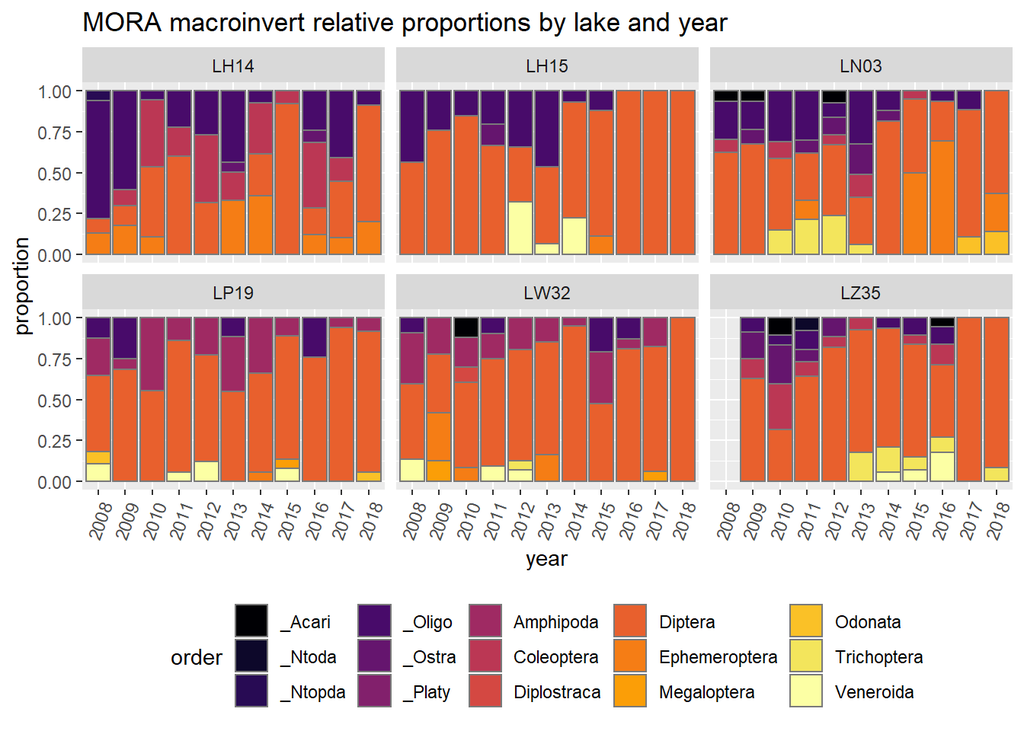

```r
mora_macro_uni_plot <- macro_props %>%
  filter(park == "MORA") %>%
  ggplot() +
  geom_bar(aes(x = year, y = proportion, fill = order),
           stat = "identity", position = "fill", color = "gray48") +
  facet_wrap(. ~ site) +
  theme(axis.text.x = element_text(angle = 70, hjust = 1),
        legend.position = "bottom") +
  scale_fill_viridis_d(option = "inferno")
```

#### Distance-based redundancy analysis (dbRDA)

vegan::capscale()/dbRDA() documentation: *Distance-based redundancy analysis (dbRDA) is an ordination method similar to Redundancy Analysis (rda), but it allows non-Euclidean dissimilarity indices, such as Manhattan or Bray–Curtis distance. Despite this non-Euclidean feature, the analysis is strictly linear and metric. If called with Euclidean distance, the results are identical to rda, but dbRDA will be less efficient. Functions capscale and dbrda are constrained versions of metric scaling, a.k.a. principal coordinates analysis, which are based on the Euclidean distance but can be used, and are more useful, with other dissimilarity measures. The functions can also perform unconstrained principal coordinates analysis, optionally using extended dissimilarities.*

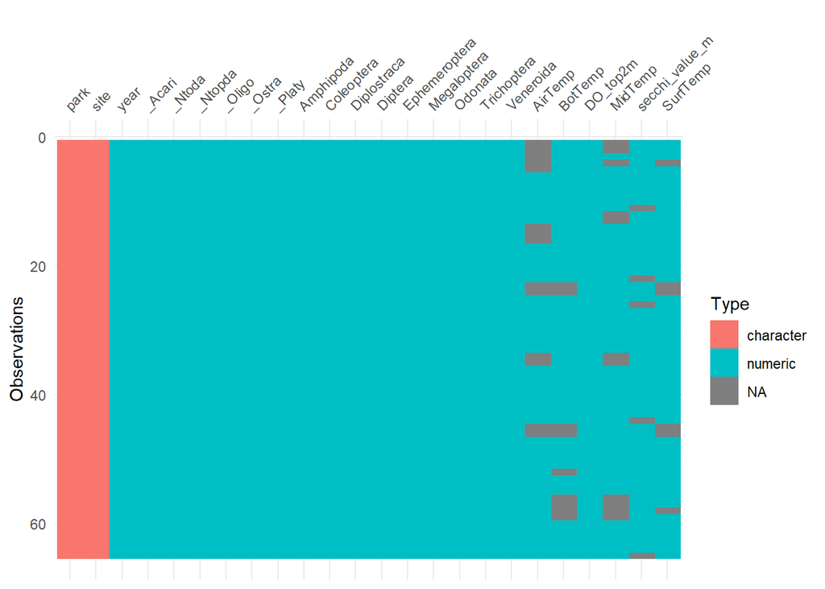

```r
macro_std_ids <- macro_std_ids %>%
  mutate(year = as.numeric(year))

yearly_bigjoin <- bigjoin %>%
  filter(variable %in% c("secchi_value_m", "AirTemp", "BotTemp",
                         "MidTemp", "SurfTemp", "DO_top2m")) %>%
  select(park_code, site_code, event_year, variable, value) %>%
  unique() %>%
  spread(key = variable, value = value)

# Join the macros to yearly_bigjoin bc some data will be NA: both datasets
# should have corresponding rows
yearly_bigjoin_macro <- inner_join(x = macro_std_ids, y = yearly_bigjoin,
                                   by = c("park" = "park_code",
                                          "site" = "site_code",
                                          "year" = "event_year"))

# NOTE: macro_std_ids has 126 rows but the join cuts it down to 65...why?
# I think this is because the macros might have better temporal coverage than
# the variable in bigjoin...

vis_dat(x = yearly_bigjoin_macro)
```

Now look at env variable correlations, but first check for and remove NAs

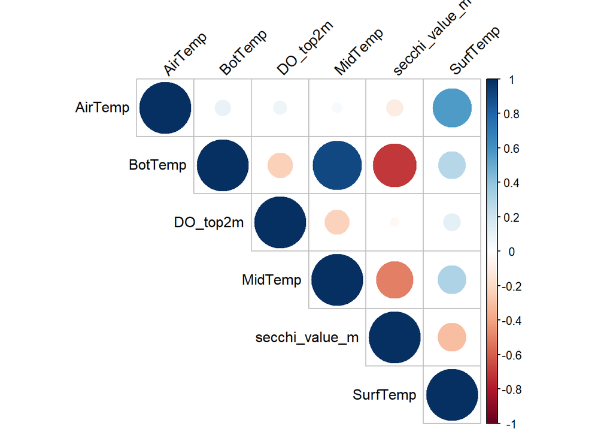

```r
# Down to 39 rows after removing NAs...
yearly_bigjoin_macro <- na.omit(yearly_bigjoin_macro)

corrplot(cor(select(yearly_bigjoin_macro, AirTemp:SurfTemp)), type = "upper",
         tl.col = "black", tl.srt = 45)
```

```r
# corr.test(x = select(yearly_bigjoin_macro, AirTemp:SurfaceTemp))
```

How about keep SurfTemp, drop other temps?

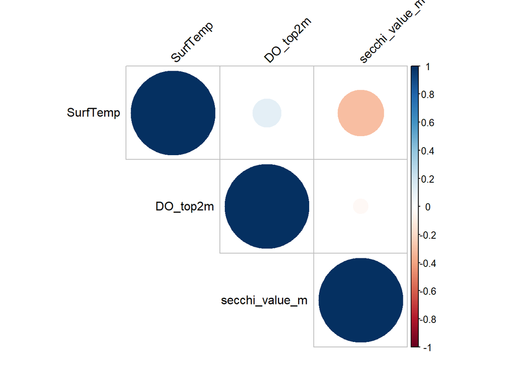

```r
corrplot(cor(select(yearly_bigjoin_macro, SurfTemp, DO_top2m, secchi_value_m)),
         type = "upper", tl.col = "black", tl.srt = 45)
```

```r
corr.test(x = select(yearly_bigjoin_macro, SurfTemp, DO_top2m, secchi_value_m))
```

```
## Call:corr.test(x = select(yearly_bigjoin_macro, SurfTemp, DO_top2m,
##     secchi_value_m))
## Correlation matrix
##                SurfTemp DO_top2m secchi_value_m
## SurfTemp           1.00     0.11          -0.30
## DO_top2m           0.11     1.00          -0.03
## secchi_value_m    -0.30    -0.03           1.00
## Sample Size
## [1] 39
## Probability values (Entries above the diagonal are adjusted for multiple tests.)
##                SurfTemp DO_top2m secchi_value_m
## SurfTemp           0.00     0.98           0.19
## DO_top2m           0.49     0.00           0.98
## secchi_value_m     0.06     0.84           0.00
##
##  To see confidence intervals of the correlations, print with the short=FALSE option
```

Run dbRDA. Note that it doesn’t provide species score (capscale() does).

**Note** that in joining in the environmental data and removing NAs, we’ve lost 87 rows (69%) of data compared with the matrix used for producing the previous nmds output.

```r
macro_dbrda <- dbrda(formula = select(yearly_bigjoin_macro, `_Acari`:Veneroida) ~
                       SurfTemp + DO_top2m + secchi_value_m, data = yearly_bigjoin_macro,
                     distance = "bray")

macro_dbrda
```

```
## Call: dbrda(formula = select(yearly_bigjoin_macro, `_Acari`:Veneroida)
## ~ SurfTemp + DO_top2m + secchi_value_m, data = yearly_bigjoin_macro,
## distance = "bray")
##
##               Inertia Proportion Rank RealDims
## Total          4.3861     1.0000
## Constrained    0.7898     0.1801    3        3
## Unconstrained  3.5963     0.8199   34       18
## Inertia is squared Bray distance
##
## Eigenvalues for constrained axes:
## dbRDA1 dbRDA2 dbRDA3
## 0.4984 0.2506 0.0408
##
## Eigenvalues for unconstrained axes:
##   MDS1   MDS2   MDS3   MDS4   MDS5   MDS6   MDS7   MDS8
## 1.9500 0.5881 0.4777 0.3250 0.1995 0.1631 0.0956 0.0899
## (Showing 8 of 34 unconstrained eigenvalues)
```

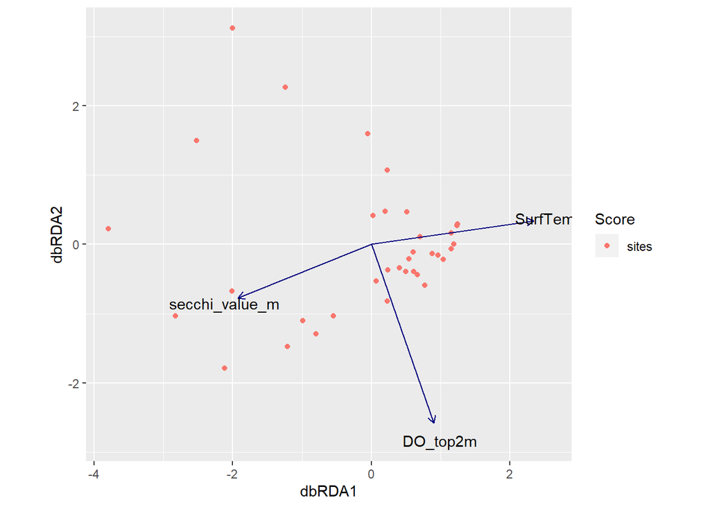

```r
autoplot(macro_dbrda)
```

The first dbRDA axis accounts for 63.1% of the variation. The second dbRDA axis accounts for 31.73% of the variation.

```r
# https://sites.ualberta.ca/~ahamann/teaching/renr690/Lab9b.pdf
anova(macro_dbrda)
```

```
## Permutation test for dbrda under reduced model
## Permutation: free
## Number of permutations: 999
##
## Model: dbrda(formula = select(yearly_bigjoin_macro, `_Acari`:Veneroida) ~ SurfTemp + DO_top2m + secchi_value_m, data = yearly_bigjoin_macro, distance = "bray")
##          Df SumOfSqs      F Pr(>F)
## Model     3   0.7898 2.5622  0.018 *
## Residual 35   3.5963
## ---
## Signif. codes:  0 '***' 0.001 '**' 0.01 '*' 0.05 '.' 0.1 ' ' 1
```

```r
anova(macro_dbrda, by = "axis", perm.max = 999)
```

```
## Permutation test for dbrda under reduced model
## Forward tests for axes
## Permutation: free
## Number of permutations: 999
##
## Model: dbrda(formula = select(yearly_bigjoin_macro, `_Acari`:Veneroida) ~ SurfTemp + DO_top2m + secchi_value_m, data = yearly_bigjoin_macro, distance = "bray")
##          Df SumOfSqs      F Pr(>F)
## dbRDA1    1   0.4984 4.8503  0.067 .
## dbRDA2    1   0.2506 2.4391  0.177
## dbRDA3    1   0.0408 0.3973  0.805
## Residual 35   3.5963
## ---
## Signif. codes:  0 '***' 0.001 '**' 0.01 '*' 0.05 '.' 0.1 ' ' 1
```

```r
anova(macro_dbrda, by = "terms", perm.max = 999)
```

```
## Permutation test for dbrda under reduced model
## Terms added sequentially (first to last)
## Permutation: free
## Number of permutations: 999
##
## Model: dbrda(formula = select(yearly_bigjoin_macro, `_Acari`:Veneroida) ~ SurfTemp + DO_top2m + secchi_value_m, data = yearly_bigjoin_macro, distance = "bray")
##                Df SumOfSqs      F Pr(>F)
## SurfTemp        1   0.3767 3.6660  0.023 *
## DO_top2m        1   0.2589 2.5197  0.074 .
## secchi_value_m  1   0.1542 1.5009  0.195
## Residual       35   3.5963
## ---
## Signif. codes:  0 '***' 0.001 '**' 0.01 '*' 0.05 '.' 0.1 ' ' 1
```

Run another NDMS, this time on the version of the community matrix that made it into the dbRDA. It’s a subset of the full one used for the earlier nmds_3:

```r
subset_nmds <- metaMDS(comm = select(yearly_bigjoin_macro, `_Acari`:Veneroida),
                       distance = "bray", k = 2, trymax = 100)
```

```
##
## Call:
## metaMDS(comm = select(yearly_bigjoin_macro, `_Acari`:Veneroida),      distance = "bray", k = 2, trymax = 100)
##
## global Multidimensional Scaling using monoMDS
##
## Data:     select(yearly_bigjoin_macro, `_Acari`:Veneroida)
## Distance: bray
##
## Dimensions: 2
## Stress:     0.1061891
## Stress type 1, weak ties
## Two convergent solutions found after 20 tries
## Scaling: centring, PC rotation, halfchange scaling
## Species: expanded scores based on 'select(yearly_bigjoin_macro, `_Acari`:Veneroida)'
```

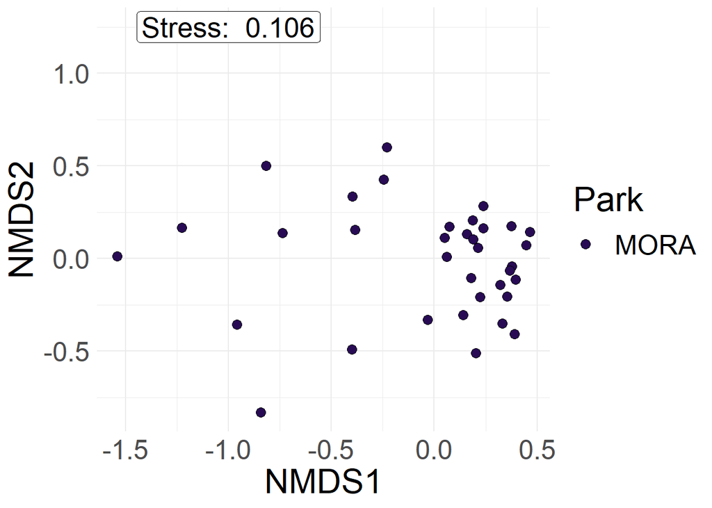

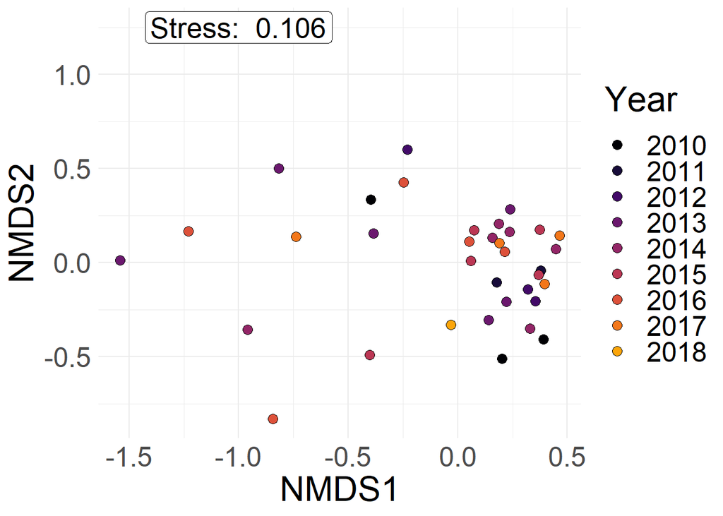

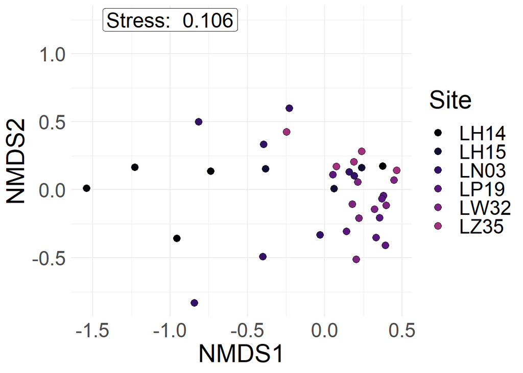